# Analyzing data on bicycle rental

Kolomiiets Ruslan

2025-03-20

# Case study “Cyclistic”

Cyclistic has 692 bike sharing stations across Chicago. The bikes can be unlocked from one station and returned to any other station in the system at any time. Customers who buy single-ride or full-day passes are called casual users. Customers who purchase annual passes are called Cyclistic members.

Cyclistic’s financial analysts have concluded that annual passes are much more profitable than occasional ones. Instead of creating a marketing campaign aimed at new customers, there is a good opportunity to turn casual cyclists into club members. To do this, it is necessary to develop marketing strategies aimed at converting casual cyclists into annual members. To do so, however, the team needed to better understand the differences between annual members and casual users, why casual users purchase memberships, and how digital media can impact their marketing tactics.

Outline of the report:

1. Terms of reference
2. Formulation of the business task
3. Description of all used data sources
4. Documentation of any data cleaning or manipulation
5. A summary of the analysis
6. Key conclusions
7. Recommendations based on the analysis

# 1. Statement of Work

**Purpose:** the project was developed as part of the educational process at the [Google Data Analytics Professional Certificate](https://www.coursera.org/professional-certificates/google-data-analytics).

**Data Analyst:** Ruslan Kolomiets

**Client:** Cyclistic - bike-share company

**Research objective:** Do annual members and casual riders use Cyclistic bikes differently?

## Scope / Major Project Activities:

**Data collection** obtain data tables, clean them and prepare for the study

**Search for dependencies** analyze parameters and find trends in the data

**Provide research conclusions** draw and communicate conclusions on the research conducted

## This project does not include:

- research beyond the scope of the ToR
- conclusions and forecasts that are not included in the task description
- complex statistical calculations

# 2. Formulation of the business task

The management of Cyclistic has asked us to answer the following question: What is the difference in bike usage between annual users and occasional customers?

## Task statement:

Using the existing data, it is necessary to analyze users, determine their characteristics, preferences, and find out their behavioral trends.

We define the criteria by which users can be evaluated.

- **user type** - *Subscriber, Customer*
- **user age**
- **user gender** - *Male, Female*
- **duration of the trip**
- **type of trip** - *in one direction (one_way) or with a return to the starting docking stations (return)*
- **type of day of the week** - *weekdays, working days, (holidays of the week - no information is available)*
- **times of day**
- **months of the year**

# 3. Description of data and sources used

**Data used:** Divvy data, Divvy’s accumulated travel data, is for public use. The data is provided in accordance with the Divvy Data License Agreement, [license agreement.](https://divvybikes.com/data-license-agreement).

The data is reliable, does not have any confidential information, and does not pose any risks in terms of data security.

The data covers the period of 2019, consists of four csv files containing data on a quarterly basis.

The data in the files consists of the following columns:

**trip_id** - *a unique trip identifier*

**start_time** - *day and time of the trip start (M/d/yyyy hh:mm)*

**end_time** _- *day and time of the trip end (M/d/yyyy hh:mm)*

**bikeid** - *bike identification number*

**tripduration** - *duration of the trip*

**from_station_id** - *unique docking stations identifier*

**from_station_name** - *the name of the docking stations where the trip started*

**to_station_id** - *unique docking stations identifier*

**to_station_name** - *the name of the docking stations where the trip ended*

**usertype** - *type of user (user with a subscription, random user)*

**gender** - *user’s gender*

**birthyear** - *the year of birth of the user*

Columns created for convenience in the data preparation process:

**d_2019$age** - *user’s age*

**d_2019$tripduration_min** - *trip duration in minutes*

**d_2019$trip_type** - *type of trip, one way or return*

**d_2019$day_type** - *determining the type of day: day off or working day*

**d_2019$age_group** - *age groups*

# 4. Cleaning and manipulating data

Make a backup copy of all files beforehand.

To work with data in the R environment, download the following libraries:

```r
library(tidyverse) # a set of packages for data processing in R
library(dplyr) # for working with dataframes
library(readr) # for working with CSV and text files
library(lubridate) # for working with dates and times
library(ggplot2) # for data visualization
library(scales) # to change the format of axis labels
```

Import files:

```r
d_2019_q1 <- read_csv("D:/Google Data Analytics/! Cyclistic/Divvy_Trips_2019_Q1.csv")
d_2019_q2 <- read_csv("D:/Google Data Analytics/! Cyclistic/Divvy_Trips_2019_Q2.csv")
d_2019_q3 <- read_csv("D:/Google Data Analytics/! Cyclistic/Divvy_Trips_2019_Q3.csv")
d_2019_q4 <- read_csv("D:/Google Data Analytics/! Cyclistic/Divvy_Trips_2019_Q4.csv")
```

Familiarize yourself with the data structure in each table:

```r
glimpse(d_2019_q1)
```

```
## Rows: 365,069
## Columns: 12
## $ trip_id           <dbl> 21742443, 21742444, 21742445, 21742446, 21742447, 21…
## $ start_time        <dttm> 2019-01-01 00:04:37, 2019-01-01 00:08:13, 2019-01-0…
## $ end_time          <dttm> 2019-01-01 00:11:07, 2019-01-01 00:15:34, 2019-01-0…
## $ bikeid            <dbl> 2167, 4386, 1524, 252, 1170, 2437, 2708, 2796, 6205,…
## $ tripduration      <dbl> 390, 441, 829, 1783, 364, 216, 177, 100, 1727, 336, …
## $ from_station_id   <dbl> 199, 44, 15, 123, 173, 98, 98, 211, 150, 268, 299, 2…
## $ from_station_name <chr> "Wabash Ave & Grand Ave", "State St & Randolph St", …
## $ to_station_id     <dbl> 84, 624, 644, 176, 35, 49, 49, 142, 148, 141, 295, 4…
## $ to_station_name   <chr> "Milwaukee Ave & Grand Ave", "Dearborn St & Van Bure…
## $ usertype          <chr> "Subscriber", "Subscriber", "Subscriber", "Subscribe…
## $ gender            <chr> "Male", "Female", "Female", "Male", "Male", "Female"…
## $ birthyear         <dbl> 1989, 1990, 1994, 1993, 1994, 1983, 1984, 1990, 1995…
```

```r
glimpse(d_2019_q2)
```

```
## Rows: 1,108,163
## Columns: 12
## $ `01 - Rental Details Rental ID`                    <dbl> 22178529, 22178530,…
## $ `01 - Rental Details Local Start Time`             <dttm> 2019-04-01 00:02:2…
## $ `01 - Rental Details Local End Time`               <dttm> 2019-04-01 00:09:4…
## $ `01 - Rental Details Bike ID`                      <dbl> 6251, 6226, 5649, 4…
## $ `01 - Rental Details Duration In Seconds Uncapped` <dbl> 446, 1048, 252, 357…
## $ `03 - Rental Start Station ID`                     <dbl> 81, 317, 283, 26, 2…
## $ `03 - Rental Start Station Name`                   <chr> "Daley Center Plaza…
## $ `02 - Rental End Station ID`                       <dbl> 56, 59, 174, 133, 1…
## $ `02 - Rental End Station Name`                     <chr> "Desplaines St & Ki…
## $ `User Type`                                        <chr> "Subscriber", "Subs…
## $ `Member Gender`                                    <chr> "Male", "Female", "…
## $ `05 - Member Details Member Birthday Year`         <dbl> 1975, 1984, 1990, 1…
```

```r
glimpse(d_2019_q3)
```

```
## Rows: 1,640,718
## Columns: 12
## $ trip_id           <dbl> 23479388, 23479389, 23479390, 23479391, 23479392, 23…
## $ start_time        <dttm> 2019-07-01 00:00:27, 2019-07-01 00:01:16, 2019-07-0…
## $ end_time          <dttm> 2019-07-01 00:20:41, 2019-07-01 00:18:44, 2019-07-0…
## $ bikeid            <dbl> 3591, 5353, 6180, 5540, 6014, 4941, 3770, 5442, 2957…
## $ tripduration      <dbl> 1214, 1048, 1554, 1503, 1213, 310, 1248, 1550, 1583,…
## $ from_station_id   <dbl> 117, 381, 313, 313, 168, 300, 168, 313, 43, 43, 511,…
## $ from_station_name <chr> "Wilton Ave & Belmont Ave", "Western Ave & Monroe St…
## $ to_station_id     <dbl> 497, 203, 144, 144, 62, 232, 62, 144, 195, 195, 84, …
## $ to_station_name   <chr> "Kimball Ave & Belmont Ave", "Western Ave & 21st St"…
## $ usertype          <chr> "Subscriber", "Customer", "Customer", "Customer", "C…
## $ gender            <chr> "Male", NA, NA, NA, NA, "Male", NA, NA, NA, NA, NA, …
## $ birthyear         <dbl> 1992, NA, NA, NA, NA, 1990, NA, NA, NA, NA, NA, NA, …
```

```r
glimpse(d_2019_q4)
```

```
## Rows: 704,054
## Columns: 12
## $ trip_id           <dbl> 25223640, 25223641, 25223642, 25223643, 25223644, 25…
## $ start_time        <dttm> 2019-10-01 00:01:39, 2019-10-01 00:02:16, 2019-10-0…
## $ end_time          <dttm> 2019-10-01 00:17:20, 2019-10-01 00:06:34, 2019-10-0…
## $ bikeid            <dbl> 2215, 6328, 3003, 3275, 5294, 1891, 1061, 1274, 6011…
## $ tripduration      <dbl> 940, 258, 850, 2350, 1867, 373, 1072, 1458, 1437, 83…
## $ from_station_id   <dbl> 20, 19, 84, 313, 210, 156, 84, 156, 156, 336, 77, 19…
## $ from_station_name <chr> "Sheffield Ave & Kingsbury St", "Throop (Loomis) St …
## $ to_station_id     <dbl> 309, 241, 199, 290, 382, 226, 142, 463, 463, 336, 50…
## $ to_station_name   <chr> "Leavitt St & Armitage Ave", "Morgan St & Polk St", …
## $ usertype          <chr> "Subscriber", "Subscriber", "Subscriber", "Subscribe…
## $ gender            <chr> "Male", "Male", "Female", "Male", "Male", "Female", …
## $ birthyear         <dbl> 1987, 1998, 1991, 1990, 1987, 1994, 1991, 1995, 1993…
```

### Verify data

One of the tables has a common structure, but it has different column names from the others. Let’s change them to match the other tables:

```r
colnames(d_2019_q2) <- colnames(d_2019_q1)
```

Combine all tables:

```r
d_2019 <- rbind(d_2019_q1, d_2019_q2, d_2019_q3, d_2019_q4)
```

We check for duplicates:

```r
nrow(d_2019[duplicated(d_2019), ])
```

```
## [1] 0
```

We check for uniqueness of values in columns of the type that are important for calculations:

```r
unique(d_2019$gender)
```

```
## [1] "Male"   "Female" NA
```

```r
unique(d_2019$usertype)
```

```
## [1] "Subscriber" "Customer"
```

Check for extra spaces in station names:

```r
d_2019[grepl("^\\s|\\s$", d_2019$from_station_name) | # check for extra spaces at the beginning and end
       grepl("^\\s|\\s$", d_2019$to_station_name) |
       grepl("  ", d_2019$from_station_name) | # check for double spaces
       grepl("  ", d_2019$to_station_name), ]
```

```
## # A tibble: 0 × 12
## # ℹ 12 variables: trip_id <dbl>, start_time <dttm>, end_time <dttm>,
## #   bikeid <dbl>, tripduration <dbl>, from_station_id <dbl>,
## #   from_station_name <chr>, to_station_id <dbl>, to_station_name <chr>,
## #   usertype <chr>, gender <chr>, birthyear <dbl>
```

Check the dates for the sequence of events:

```r
d_2019[d_2019$start_time > d_2019$end_time, ] # find trips where the departure time is greater than the arrival time
```

```
## # A tibble: 13 × 12
##     trip_id start_time          end_time            bikeid tripduration
##       <dbl> <dttm>              <dttm>               <dbl>        <dbl>
##  1 25625830 2019-11-03 01:43:21 2019-11-03 01:09:56   4141         1594
##  2 25625836 2019-11-03 01:46:01 2019-11-03 01:10:44   6329         1483
##  3 25625838 2019-11-03 01:47:49 2019-11-03 01:02:40    964          891
##  4 25625839 2019-11-03 01:48:04 2019-11-03 01:16:48   2214         1724
##  5 25625841 2019-11-03 01:50:31 2019-11-03 01:04:25   4179          834
##  6 25625843 2019-11-03 01:51:59 2019-11-03 01:03:02   2920          663
##  7 25625844 2019-11-03 01:51:55 2019-11-03 01:04:33   3338          757
##  8 25625845 2019-11-03 01:53:08 2019-11-03 01:04:53   2142          705
##  9 25625846 2019-11-03 01:53:10 2019-11-03 01:04:53   5877          703
## 10 25625847 2019-11-03 01:53:24 2019-11-03 01:06:08   3984          764
## 11 25625849 2019-11-03 01:55:33 2019-11-03 01:01:52   5059          379
## 12 25625850 2019-11-03 01:57:48 2019-11-03 01:01:26   5310          217
## 13 25625851 2019-11-03 01:58:17 2019-11-03 01:08:27   6133          609
## # ℹ 7 more variables: from_station_id <dbl>, from_station_name <chr>,
## #   to_station_id <dbl>, to_station_name <chr>, usertype <chr>, gender <chr>,
## #   birthyear <dbl>
```

delete data with incorrect dates:

```r
d_2019 <- d_2019 %>%
  filter(start_time <= end_time)
```

To detect errors, we get generalized statistics on the data:

```r
summary(d_2019)
```

```
##     trip_id           start_time
##  Min.   :21742443   Min.   :2019-01-01 00:04:37.00
##  1st Qu.:22873784   1st Qu.:2019-05-29 15:49:07.50
##  Median :23962312   Median :2019-07-25 17:50:41.00
##  Mean   :23915623   Mean   :2019-07-19 21:47:05.88
##  3rd Qu.:24963694   3rd Qu.:2019-09-15 06:24:21.00
##  Max.   :25962904   Max.   :2019-12-31 23:57:17.00
##
##     end_time                          bikeid      tripduration
##  Min.   :2019-01-01 00:11:07.00   Min.   :   1   Min.   :      61
##  1st Qu.:2019-05-29 16:09:16.00   1st Qu.:1727   1st Qu.:     411
##  Median :2019-07-25 18:12:17.00   Median :3451   Median :     709
##  Mean   :2019-07-19 22:11:16.34   Mean   :3380   Mean   :    1450
##  3rd Qu.:2019-09-15 08:27:51.00   3rd Qu.:5046   3rd Qu.:    1283
##  Max.   :2020-01-21 13:54:35.00   Max.   :6946   Max.   :10628400
##
##  from_station_id from_station_name  to_station_id   to_station_name
##  Min.   :  1.0   Length:3817991     Min.   :  1.0   Length:3817991
##  1st Qu.: 77.0   Class :character   1st Qu.: 77.0   Class :character
##  Median :174.0   Mode  :character   Median :174.0   Mode  :character
##  Mean   :201.7                      Mean   :202.6
##  3rd Qu.:289.0                      3rd Qu.:291.0
##  Max.   :673.0                      Max.   :673.0
##
##    usertype            gender            birthyear
##  Length:3817991     Length:3817991     Min.   :1759
##  Class :character   Class :character   1st Qu.:1979
##  Mode  :character   Mode  :character   Median :1987
##                                        Mean   :1984
##                                        3rd Qu.:1992
##                                        Max.   :2014
##                                        NA's   :538746
```

We observe the following:

- in the **tripduration** column, the maximum trip duration is 10628400 seconds, which looks like erroneous data
- in the **birthyear** column, the minimum year of birth is 1759, which is also erroneous

Check for missing data (NA)

```r
colSums(is.na(d_2019))
```

```
##           trip_id        start_time          end_time            bikeid
##                 0                 0                 0                 0
##      tripduration   from_station_id from_station_name     to_station_id
##                 0                 0                 0                 0
##   to_station_name          usertype            gender         birthyear
##                 0                 0            559201            538746
```

**The gender and birthyear columns have a significant amount of missing data**.

Count the number of blanks in the **gender** and **birthyear** columns for users of type **Customer**:

```r
data.frame(
  metric = c("NA in gender", "NA in birthyear", "Total Customers"),
  value = c(
    sum(is.na(d_2019$gender[d_2019$usertype == "Customer"])),
    sum(is.na(d_2019$birthyear[d_2019$usertype == "Customer"])),
    sum(d_2019$usertype == "Customer")
  )
)
```

```
##            metric  value
## 1    NA in gender 536450
## 2 NA in birthyear 532415
## 3 Total Customers 880631
```

Almost all of the data with gaps belongs to the **Customer** type. We leave this data, as it makes up the majority of the Customer type data and contains a significant amount of information about the duration of the trip.

At previous stages of calculations, significant errors were found in the data on trip duration and date of birth:

for **tripduration**:

Min: 61 Median : 709 Max: 10628400

for *birthyear**:

Min. : 1759 Median : 1987 Max. : 2014

It is necessary to remove erroneous data, but first you need to determine the limit along which the filtering will be performed and make sure that the data will not be distorted after removal. To do this, let’s assume that the maximum age of cyclists can be 80 years old and the duration of the trip is 12 hours. Let’s test this assumption:

```r
sum(!is.na(d_2019$birthyear) & d_2019$birthyear < 1939) # number of rows with age value > 80 years, (1939 year of birth)
```

```
## [1] 1147
```

```r
sum(d_2019$tripduration > 43200) # number of lines with a trip duration > 43200 seconds (12 hours)
```

```
## [1] 3945
```

```r
nrow(d_2019) # total number of observations
```

```
## [1] 3817991
```

Filter out false data:

```r
d_2019 <- d_2019 %>% filter(birthyear >= 1939 | is.na(birthyear))
d_2019 <- d_2019 %>% filter(tripduration <= 43200)
```

For convenience, we create additional calculation columns:

```r
d_2019$tripduration_min <- round(d_2019$tripduration / 60)  # conversion of trip duration to minutes
d_2019$age <- year(d_2019$start_time) - d_2019$birthyear  # calculate the user's age
d_2019$trip_type <- ifelse(d_2019$from_station_id == d_2019$to_station_id, "return", "one_way") # determining the type of trip
d_2019 <- d_2019 %>%
  mutate(day_type = ifelse(wday(start_time) %in% c(1, 7), "Weekend", "Weekday")) # defining the type of day
colnames(d_2019)
```

```
##  [1] "trip_id"           "start_time"        "end_time"
##  [4] "bikeid"            "tripduration"      "from_station_id"
##  [7] "from_station_name" "to_station_id"     "to_station_name"
## [10] "usertype"          "gender"            "birthyear"
## [13] "tripduration_min"  "age"               "trip_type"
## [16] "day_type"
```

### Analyzing the age characteristics of users

Draw a graph of the distribution of user activity by age for customers.

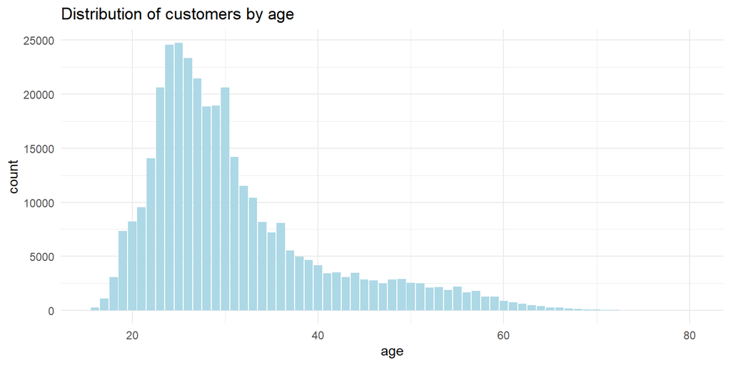

```r
ggplot(data = d_2019 %>% filter(usertype == "Customer")) +
  geom_bar(mapping = aes(x = age), fill = "lightblue") +
  labs(title = "Distribution of customers by age") +
  theme_minimal()
```

We build a graph of the distribution of user activity by age for subscribers.

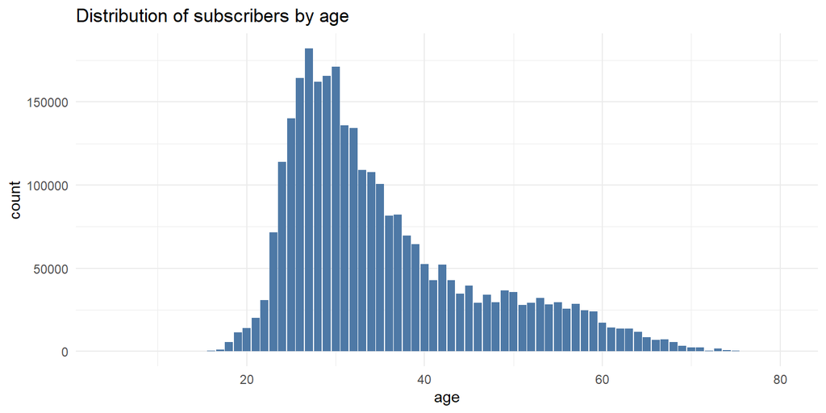

```r
ggplot(data = d_2019 %>% filter(usertype == "Subscriber")) +
  geom_bar(mapping = aes(x = age), fill = "#4e79a6") +
  labs(title = "Distribution of subscribers by age") +
  theme_minimal()
```

We observe that **customers have a shift towards younger age**.

Let’s calculate the main static indicators for each type of user:

```r
  customer_summary <- summary(d_2019 %>% filter(usertype == "Customer", !is.na(age)) %>% select(age))
  subscriber_summary <- summary(d_2019 %>% filter(usertype == "Subscriber", !is.na(age)) %>% select(age))
tibble(
  Statistic = names(customer_summary),
  Customer = as.vector(customer_summary),
  Subscriber = as.vector(subscriber_summary)
)
```

```
## # A tibble: 6 × 2
##   Customer          Subscriber
##   <chr>             <chr>
## 1 "Min.   :16.00  " "Min.   : 5.00  "
## 2 "1st Qu.:24.00  " "1st Qu.:27.00  "
## 3 "Median :28.00  " "Median :32.00  "
## 4 "Mean   :30.94  " "Mean   :35.37  "
## 5 "3rd Qu.:34.00  " "3rd Qu.:41.00  "
## 6 "Max.   :80.00  " "Max.   :80.00  "
```

Since the distribution of users is skewed, we use median values to determine the average age more accurately:

**The average age of customers is 28 years old, while the average age of subscribers is 32 years old**

For the convenience of calculations, we will divide the age of users into groups:

```r
d_2019 <- d_2019 %>%
  mutate(age_group = cut(age, breaks = seq(0, 80, by = 10),
                        labels = c("under 10", "10-19", "20-29", "30-39", "40-49", "50-59", "60-69", "70+"), ))
```

For each age group, we calculate the percentage of users:

```r
d_2019 %>% filter(!is.na(age_group)) %>%
  group_by(age_group) %>%
  summarise(
    customer_percentage = round((sum(usertype == "Customer") / n()) * 100, 0),  # Percent of customer
    subscriber_percentage = round((sum(usertype == "Subscriber") / n()) * 100, 0) # Percent of subscriber
  )
```

```
## # A tibble: 8 × 3
##   age_group customer_percentage subscriber_percentage
##   <fct>                   <dbl>                 <dbl>
## 1 under 10                    0                   100
## 2 10-19                      38                    62
## 3 20-29                      14                    86
## 4 30-39                       8                    92
## 5 40-49                       7                    93
## 6 50-59                       6                    94
## 7 60-69                       4                    96
## 8 70+                         3                    97
```

**We observe a tendency for the percentage of users without a subscription to decrease with age, and the opposite trend for customers**

### Let’s analyze the behavior of users with different genders.

We build a graph of the distribution of all users by age group for different genders:

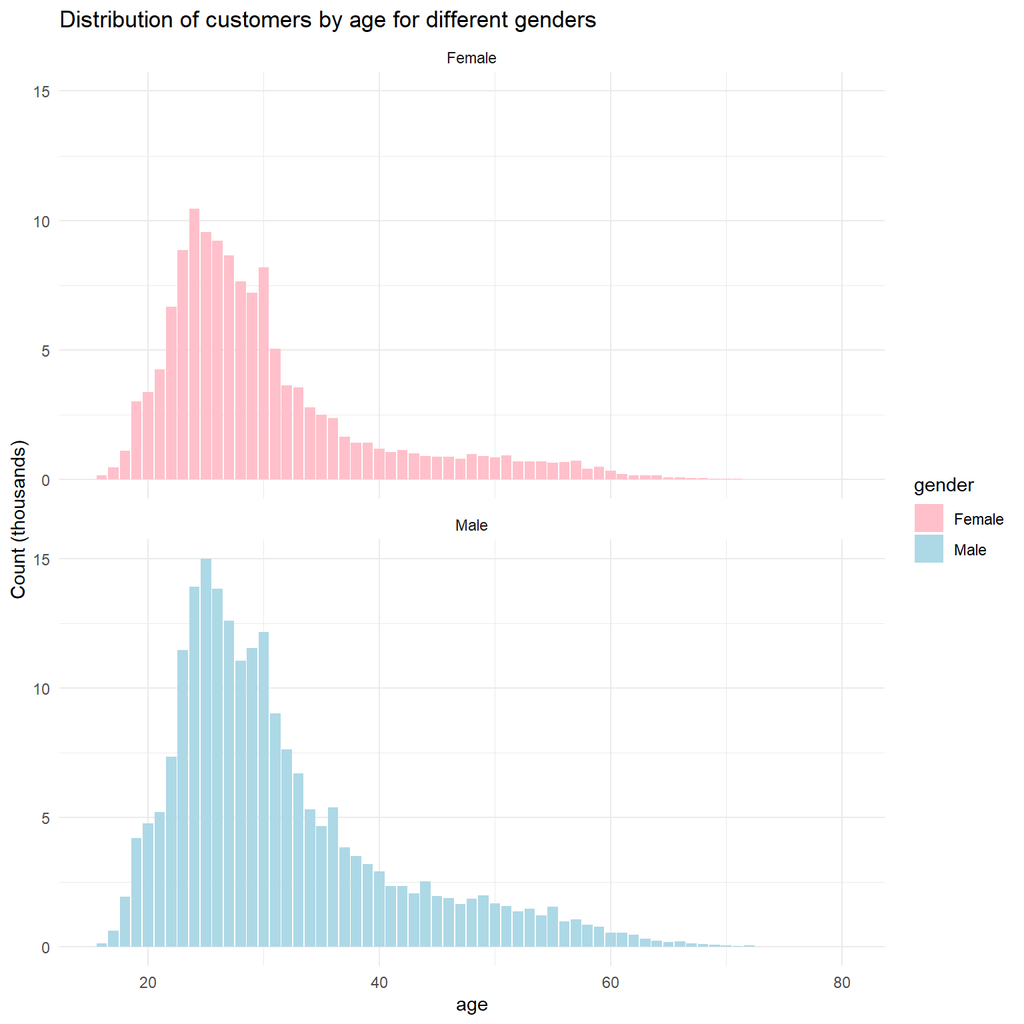

```r
ggplot(data = d_2019 %>% filter(usertype == "Customer", !is.na(gender))) +
  geom_bar(mapping = aes(x = age, fill = gender)) +  # fill depends on gender
  facet_wrap(~gender, ncol = 1) +
  scale_fill_manual(values = c("Male" = "lightblue", "Female" = "pink")) +
  scale_y_continuous(labels = label_number(scale = 1e-3))+
  labs(title = "Distribution of customers by age for different genders", y = "Count (thousands)") +
  theme_minimal()
```

The visualization shows that the age distribution among customer is similar for different genders. **There is a uniform excess of males over females**.

We calculate the percentage of women and men for each age group among customer:

```r
d_2019 %>% filter(usertype == "Customer", !is.na(age_group)) %>%
  group_by(age_group) %>%
  summarise(
    Female = round((sum(gender == "Female", na.rm = TRUE) / sum(!is.na(gender))) * 100),
    Male   = round((sum(gender == "Male", na.rm = TRUE) / sum(!is.na(gender))) * 100)
            )
```

```
## # A tibble: 7 × 3
##   age_group Female  Male
##   <fct>      <dbl> <dbl>
## 1 10-19         41    59
## 2 20-29         41    59
## 3 30-39         33    67
## 4 40-49         32    68
## 5 50-59         36    64
## 6 60-69         30    70
## 7 70+           21    79
```

Let’s calculate the percentage of women and men for each age group among subscribers:

```r
d_2019 %>% filter(usertype == "Subscriber", !is.na(gender)) %>%
  group_by(age_group) %>%
  summarise(Female = round((sum(gender == "Female", na.rm = TRUE) / sum(!is.na(gender))) * 100),
            Male = round((sum(gender == "Male", na.rm = TRUE) / sum(!is.na(gender))) * 100)
            )
```

```
## # A tibble: 8 × 3
##   age_group Female  Male
##   <fct>      <dbl> <dbl>
## 1 under 10     100     0
## 2 10-19         29    71
## 3 20-29         29    71
## 4 30-39         22    78
## 5 40-49         19    81
## 6 50-59         23    77
## 7 60-69         22    78
## 8 70+           13    87
```

**For both types of users, we observe a tendency for the share of women to decrease with increasing age**.

Let’s calculate the percentage of women for each type of user:

```r
d_2019 %>% group_by(usertype) %>%
  summarise(
    percent_female = round(100 * sum(gender == "Female", na.rm = TRUE) / sum(!is.na(gender))),
    percent_male = round(100 * sum(gender == "Male", na.rm = TRUE) / sum(!is.na(gender)))
            )
```

```
## # A tibble: 2 × 3
##   usertype   percent_female percent_male
##   <chr>               <dbl>        <dbl>
## 1 Customer               38           62
## 2 Subscriber             25           75
```

**We observe a trend of a decrease in the percentage of women among users.**

Let’s visualize the distribution of users by trip duration:

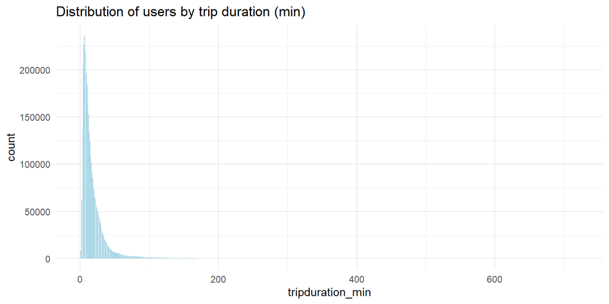

```r
ggplot(data = d_2019) +
  geom_bar(mapping = aes(x = tripduration_min), fill = "lightblue") +
  labs(title = "Distribution of users by trip duration (min)") +
  theme_minimal()
```

We observe that the most trips last less than 180 minutes. For clarity and ease of evaluation, we will limit the duration to this value and build clarifying visualizations.

Let’s build a distribution by trip duration separately for different types of users::

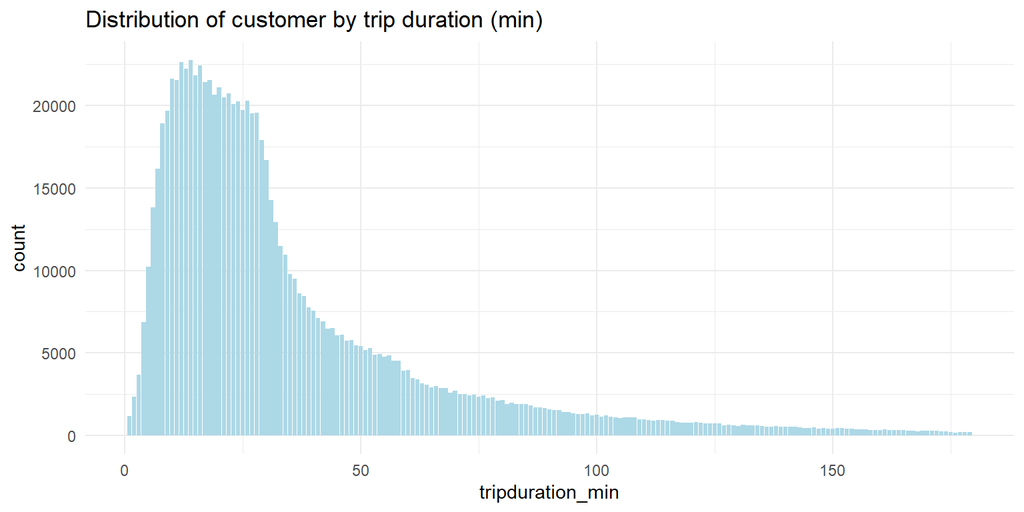

```r
ggplot(data = d_2019 %>% filter(tripduration_min < 180 & usertype == "Customer")) +
  geom_bar(mapping = aes(x = tripduration_min), fill = "lightblue") +
  labs(title = "Distribution of customer by trip duration (min)") +
  theme_minimal()
```

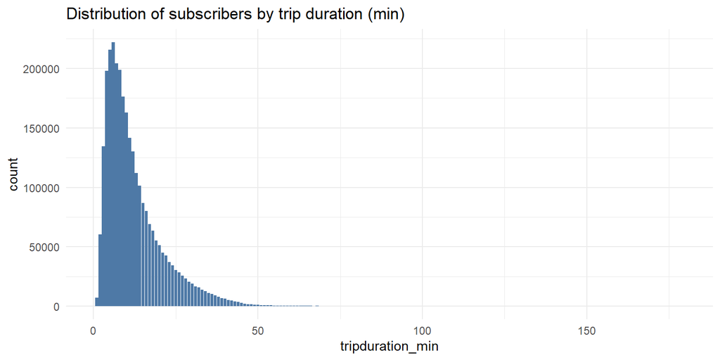

```r
ggplot(data = d_2019 %>% filter(tripduration_min < 180 & usertype == "Subscriber")) +
  geom_bar(mapping = aes(x = tripduration_min), fill = "#4e79a6") +
  labs(title = "Distribution of subscribers by trip duration (min)") +
  theme_minimal()
```

We observe that **a significant number of customers have long trips, and almost all subscribers have only short trips**.

Let’s calculate the percentage of customers who have a trip duration longer than 30 minutes:

```r
d_2019 %>%
  group_by(usertype) %>%
  summarise(percent_long_trips = round(100 * sum(tripduration_min > 30) / sum(!is.na(tripduration_min))))
```

```
## # A tibble: 2 × 2
##   usertype   percent_long_trips
##   <chr>                   <dbl>
## 1 Customer                   40
## 2 Subscriber                  5
```

We observe that **trips longer than 30 minutes are made by 40% of customers without a subscription and only 5% of customers with a subscription**.

Let’s calculate the main static indicators of the trip duration for each type of user:

```r
summary(d_2019 %>%
          filter(usertype == "Customer") %>%
          select(tripduration_min))
```

```
##  tripduration_min
##  Min.   :  1.00
##  1st Qu.: 15.00
##  Median : 26.00
##  Mean   : 37.71
##  3rd Qu.: 45.00
##  Max.   :720.00
```

```r
summary(d_2019 %>%
          filter(usertype == "Subscriber") %>%
          select(tripduration_min))
```

```
##  tripduration_min
##  Min.   :  1.00
##  1st Qu.:  6.00
##  Median : 10.00
##  Mean   : 12.73
##  3rd Qu.: 16.00
##  Max.   :720.00
```

**The average trip duration for users without a subscription is 26 minutes, for users with a subscription 10 minutes**.

### Let’s analyze user behavior in terms of trip type

Let’s calculate how different types of users use the service:

```r
d_2019 %>% group_by(usertype) %>%
  summarise(
    percent_one_way = round(100 * sum(trip_type == "one_way") / n()),
    percent_return = round(100 * sum(trip_type == "return") / n())
    )
```

```
## # A tibble: 2 × 3
##   usertype   percent_one_way percent_return
##   <chr>                <dbl>          <dbl>
## 1 Customer                88             12
## 2 Subscriber              98              2
```

We observe that **both types of users are more likely to use bicycles for trips in the same direction, i.e., there are no significant differences**. In the context of this study, this information will be considered insignificant.

### Let’s analyze user behavior on weekdays and weekends.

Let’s calculate the ratios of activities of different types of users:

```r
d_2019 %>%
  group_by(usertype) %>%
  summarise(
    percent_weekday = round(100 * sum(day_type == "Weekday", na.rm = TRUE) / n()),
    percent_weekend = round(100 * sum(day_type == "Weekend", na.rm = TRUE) / n())
  )
```

```
## # A tibble: 2 × 3
##   usertype   percent_weekday percent_weekend
##   <chr>                <dbl>           <dbl>
## 1 Customer                57              43
## 2 Subscriber              82              18
```

We observe that **customers have a slight overlap in using the service on weekdays. 80% of subscribers use the service on weekdays**.

### Let’s analyze user behavior throughout the day.

Let’s build a graph of customer activity during the day for weekends:

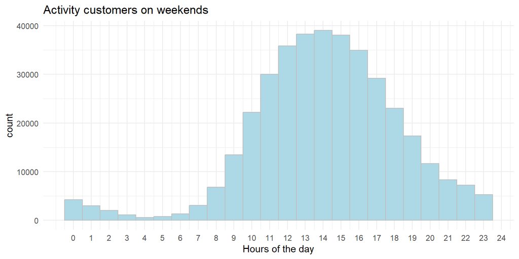

```r
ggplot(data = d_2019 %>% filter(usertype == "Customer" & day_type == "Weekend")) +
  geom_histogram(mapping = aes(x = hour(start_time)),
                 bins = 24, fill = "lightblue", color = "grey") +
   scale_x_continuous(breaks = 0:24) +
  labs(title = "Activity customers on weekends",
       x = "Hours of the day") +
  theme_minimal()
```

Let’s build a graph of subscriber activity during the day for weekends:

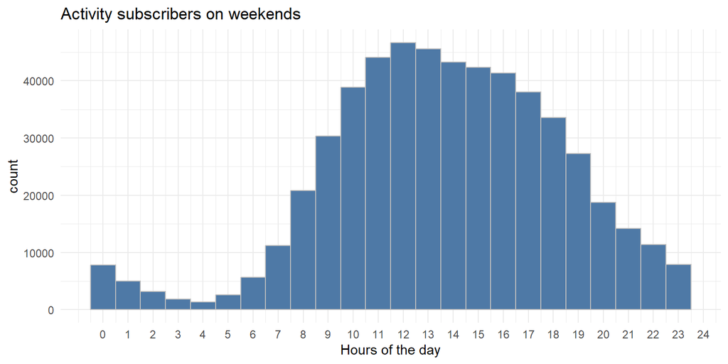

```r
ggplot(data = d_2019 %>% filter(usertype == "Subscriber" & day_type == "Weekend")) +
  geom_histogram(mapping = aes(x = hour(start_time)),
                 bins = 24, fill = "#4e79a6", color = "grey") +
   scale_x_continuous(breaks = 0:24) +
  labs(title = "Activity subscribers on weekends",
       x = "Hours of the day") +
  theme_minimal()
```

**We observe a slow increase in activity until lunchtime, followed by a slow decline for both types of users.**

Let’s build a graph of customer activity for working days of the week:

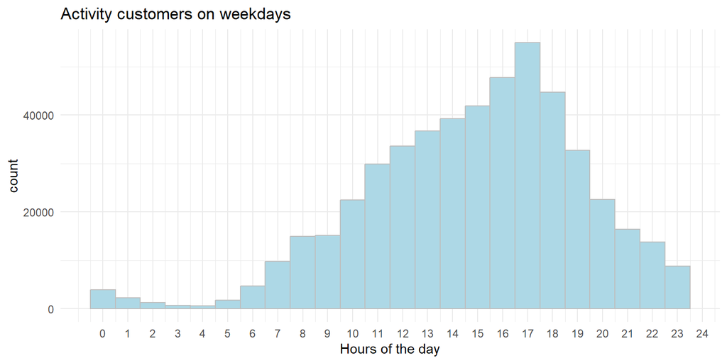

```r
ggplot(data = d_2019 %>% filter(usertype == "Customer" & day_type == "Weekday")) +
  geom_histogram(mapping = aes(x = hour(start_time)),
                 bins = 24, fill = "lightblue", color = "grey") +
  scale_x_continuous(breaks = 0:24) +
  labs(title = "Activity customers on weekdays",
       x = "Hours of the day") +
  theme_minimal()
```

Let’s build a graph of subscriber activity for weekdays:

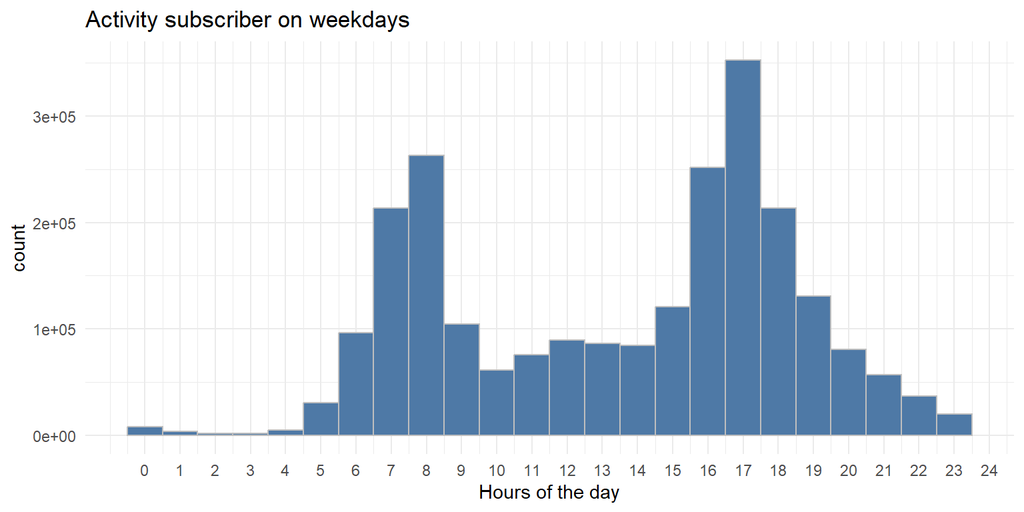

```r
ggplot(data = d_2019 %>% filter(usertype == "Subscriber" & day_type == "Weekday")) +
  geom_histogram(mapping = aes(x = hour(start_time)),
                 bins = 24, fill = "#4e79a6", color = "grey") +
  scale_x_continuous(breaks = 0:24) +
  labs(title = "Activity subscriber on weekdays",
       x = "Hours of the day") +
  theme_minimal()
```

### Let’s analyze user behavior throughout the year

We will build an activity graph for customer:

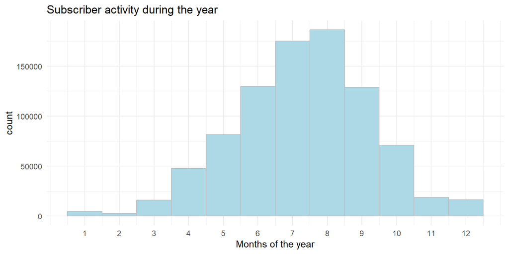

```r
ggplot(data = d_2019 %>% filter(usertype == "Customer")) +
  geom_histogram(mapping = aes(x = month(start_time)),
                 bins = 12, fill = "lightblue", color = "grey") +
  scale_x_continuous(breaks = 1:12) +
  labs(title = "Subscriber activity during the year",
       x = "Months of the year") +
  theme_minimal()
```

Let’s build an activity graph for subscribers:

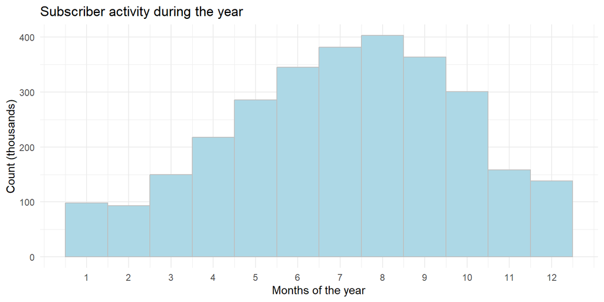

```r
ggplot(data = d_2019 %>% filter(usertype == "Subscriber")) +
  geom_histogram(mapping = aes(x = month(start_time)),
                 bins = 12, fill = "lightblue", color = "grey") +
  scale_x_continuous(breaks = 1:12) +
  scale_y_continuous(labels = label_number(scale = 1e-3))+
  labs(title = "Subscriber activity during the year",
       x = "Months of the year",
       y = "Count (thousands)") +
  theme_minimal()
```

We observe **a compressed form of the distribution of customers. The main activity falls on the period from late spring to early fall, with the maximum indicators in August. Subscribers have a stretched distribution, with no breaks in activity in winter.**

We will determine the list of docking stations that are in the highest demand among customers during the periods of highest activity. Let’s do this separately for a long-term marketing campaign, such as billboards, and consider the most active months, and separately for short-term campaigns, such as flyer distribution, etc. We calculate the most popular 10 docking stations for the period from June to October:

```r
d_2019 %>%
  filter(usertype == "Customer" &
         start_time >= as.Date("2019-06-01") &
         start_time <= as.Date("2019-10-31")) %>%
  group_by(from_station_name) %>%
  summarise(total_trips = n()) %>%
  arrange(desc(total_trips)) %>%
  head(10)
```

```
## # A tibble: 10 × 2
##    from_station_name            total_trips
##    <chr>                              <int>
##  1 Streeter Dr & Grand Ave            42713
##  2 Lake Shore Dr & Monroe St          29818
##  3 Michigan Ave & Oak St              17444
##  4 Millennium Park                    17201
##  5 Lake Shore Dr & North Blvd         16313
##  6 Shedd Aquarium                     15273
##  7 Theater on the Lake                12448
##  8 Dusable Harbor                      9823
##  9 Michigan Ave & Washington St        9034
## 10 Adler Planetarium                   9000
```

We calculate the 10 most popular docking stations for the period from June to October for weekdays:

```r
d_2019 %>%
  filter(usertype == "Customer" &
         start_time >= as.Date("2019-06-01") &
         start_time <= as.Date("2019-10-31") &
         day_type == "Weekday" &
         hour(start_time) >= 11 &
         hour(start_time) <= 20) %>%
  group_by(from_station_name) %>%
  summarise(total_trips = n()) %>%
  arrange(desc(total_trips)) %>%
  head(10)
```

```
## # A tibble: 10 × 2
##    from_station_name            total_trips
##    <chr>                              <int>
##  1 Streeter Dr & Grand Ave            20747
##  2 Lake Shore Dr & Monroe St          14655
##  3 Shedd Aquarium                      8412
##  4 Millennium Park                     7738
##  5 Lake Shore Dr & North Blvd          7644
##  6 Michigan Ave & Oak St               7535
##  7 Theater on the Lake                 5677
##  8 Dusable Harbor                      4781
##  9 Adler Planetarium                   4569
## 10 Michigan Ave & Washington St        4406
```

We calculate the 10 most popular docking stations for the period from June to October for weekends:

```r
d_2019 %>%
  filter(usertype == "Customer" &
         start_time >= as.Date("2019-06-01") &
         start_time <= as.Date("2019-10-31") &
         day_type == "Weekend" &
         hour(start_time) >= 10 &
         hour(start_time) <= 17) %>%
  group_by(from_station_name) %>%
  summarise(total_trips = n()) %>%
  arrange(desc(total_trips)) %>%
  head(10)
```

```
## # A tibble: 10 × 2
##    from_station_name          total_trips
##    <chr>                            <int>
##  1 Streeter Dr & Grand Ave          13701
##  2 Lake Shore Dr & Monroe St         9112
##  3 Lake Shore Dr & North Blvd        6249
##  4 Michigan Ave & Oak St             5629
##  5 Millennium Park                   5310
##  6 Shedd Aquarium                    4874
##  7 Theater on the Lake               4622
##  8 Dusable Harbor                    3204
##  9 Adler Planetarium                 2813
## 10 Montrose Harbor                   2315
```

We observe that the most popular docking stations differ slightly from day to day, but they do differ. Export the file to build the dashboard:

```r
write.csv(d_2019, "D:/Google Data Analytics/! Cyclistic/d_2019_exp.csv", row.names = FALSE)
```

# 5. Summary of the Analysis

### Preliminary Remarks

During the analysis, the behavior and characteristics of different types of users were examined.

The age and gender characteristics of the users, the dynamics of their behavior, and trends were identified.

No complex statistical calculations were conducted in this study.

For a more detailed and objective analysis, customer IDs are needed to identify multiple uses of the service. This would allow for identifying users more likely to transition to a subscription, as well as excluding one-time uses of the service, such as tourist trips, one-time walks, or other incidental uses.

### Information Obtained During the Analysis

The average age of users without a subscription is 28 years, while the average age of subscribers is 32 years. This indicates a shift towards a younger age group among users without a subscription. The service is most popular among users aged 19 to 36 for non-subscribers and between 24 and 42 for subscribers.

The percentage of women among non-subscribers (38%) is higher than among subscribers (25%).

Long trips (> 30 minutes) are made by 40% of non-subscribers and only 5% of subscribers.

Non-subscribers use the service more frequently on weekends, while subscribers tend to use it more on weekdays.

The behavior of both user types on weekends is similar: activity gradually increases from the morning until lunchtime, then slowly decreases in the evening.

On weekdays, there is a significant difference: non-subscribers exhibit behavior similar to weekends, while subscribers have two peaks of activity – from 7:00 to 10:00 and from 16:00 to 20:00.

The activity of non-subscribers throughout the year is uneven: there is a pause in the winter period, with the main activity occurring from late spring to early autumn. Subscribers are active year-round, with a gradual increase in activity, a peak in August, and a subsequent slow decline.

The most popular stations during the most active periods have been identified.

# 6. Key Findings

The most active segment of non-subscribers is several years younger than the most active segment of subscribers.

A significant portion of non-subscribers uses the service mainly in spring, summer, and autumn, while subscribers use it year-round.

Non-subscribers take longer trips than subscribers.

Non-subscribers use the service more frequently on weekends, while subscribers use it more often on weekdays.

# 7. Top Recommendations Based on Your Analysis

Given that non-subscriber clients take longer trips, periodic SMS or email campaigns can be conducted, offering a promotion that increases the trip duration limit on weekends during the active season when purchasing an annual subscription.

Develop a program to ensure that the most popular stations are adequately supplied with bicycles on days of high demand.

Increase the percentage of bicycles that are more suitable for women.